# Analyse Bivariée : Prix vs Marché des Produits de Thé

KOUASSI KONAN LEGER

2025-06-05

# Analyse Bivariée : Prix vs Marché

## 1. Chargement des Données et Packages

```r
# Chargement des packages nécessaires
library(readxl)
library(tidyverse)
library(dplyr)
library(lubridate)
library(wordcloud)
library(tidytext)
library(scales)

# Nettoyage de l'environnement
rm(list = ls())
# Importation des données
gnpd <- read_excel("GNPD_tea.xlsx")

gnpd <- gnpd %>%
  mutate(
    `Price per 100 g/ml in Euros` = as.numeric(`Price per 100 g/ml in Euros`),
    `Price in US Dollars` = as.numeric(`Price in US Dollars`),
    `Price in Euros` = as.numeric(`Price in Euros`),
    `Unit Pack Size (ml/g)` = as.numeric(`Unit Pack Size (ml/g)`),
    `Alcohol By Volume (%)` = as.numeric(`Alcohol By Volume (%)`),
    `Bar Code` = as.character(`Bar Code`),
    `Date Published` = as.Date(`Date Published`)
  )

# Filtrage des sous-catégories d'intérêt
gnpd <- gnpd %>%
  filter(`Sub-Category` %in% c("Tea", "RTD (Iced) Tea")) %>%
  filter(!is.na(`Price per 100 g/ml in Euros`))
# Étape 1 : Filtrer et calculer la proportion
total_lignes <- nrow(gnpd)

gnpd_filtre <- gnpd %>%
  filter(`Unit Pack Size (ml/g)` >= 2,
         `Price per 100 g/ml in Euros`!= 0.00)
gnpd_filtre <- gnpd_filtre %>%
  filter(`Unit Pack Size (ml/g)` <= 5000)

proportion_conservee <- nrow(gnpd_filtre) / total_lignes

# Affichage de la proportion conservée
proportion_conservee
```

```
## [1] 0.9247157
```

## 2. Analyse Descriptive

### 2.1 Résumé Statistique des Variables

```r
# Résumé statistique du prix
summary_prix <- summary(gnpd$`Price per 100 g/ml in Euros`)
print("Résumé statistique du prix :")
```

```
## [1] "Résumé statistique du prix :"
```

```r
print(summary_prix)
```

```
##    Min. 1st Qu.  Median    Mean 3rd Qu.    Max.
##   0.000   0.290   2.000   5.768   7.280 404.360
```

```r
# Nombre de marchés uniques
n_marches <- length(unique(gnpd$Market))
print(paste("Nombre de marchés uniques :", n_marches))
```

```
## [1] "Nombre de marchés uniques : 86"
```

### 2.2 Analyse des Bornes de Tukey

```r
library(dplyr)
library(ggplot2)
library(forcats)

# 1. Calcul des bornes de Tukey
prix <- gnpd$`Price per 100 g/ml in Euros`
prix <- na.omit(prix)
Q1 <- quantile(prix, 0.25)
Q3 <- quantile(prix, 0.75)
IQR <- Q3 - Q1
borne_inf <- Q1 - 1.5 * IQR
borne_sup <- Q3 + 1.5 * IQR

# Affichage des bornes pour info
cat("Limites de Tukey : [", round(borne_inf, 2), ";", round(borne_sup, 2), "]\n")
```

```
## Limites de Tukey : [ -10.2 ; 17.76 ]
```

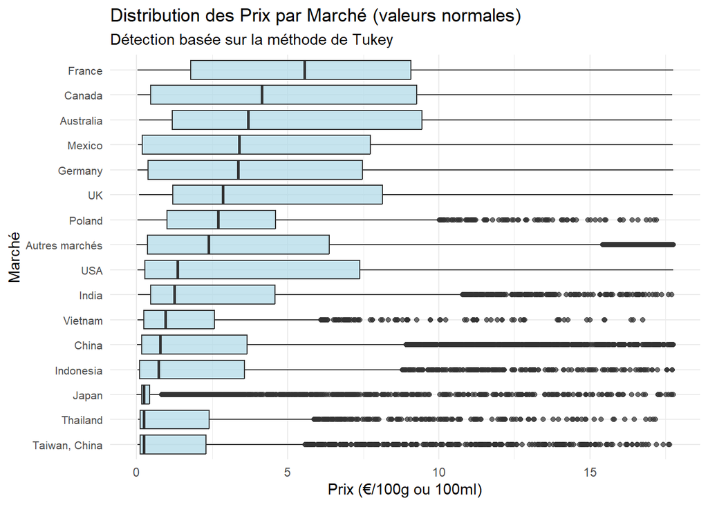

```r
# 2. Graphique : Prix normaux (dans les bornes)
ggplot(gnpd %>%
         filter(!is.na(`Price per 100 g/ml in Euros`),
                `Price per 100 g/ml in Euros` >= borne_inf,
                `Price per 100 g/ml in Euros` <= borne_sup) %>%
         mutate(Market = fct_lump(Market, n = 15, other_level = "Autres marchés")),
       aes(x = reorder(Market, `Price per 100 g/ml in Euros`, FUN = median),
           y = `Price per 100 g/ml in Euros`)) +
  geom_boxplot(fill = "lightblue", alpha = 0.7) +
  coord_flip() +
  labs(
    title = "Distribution des Prix par Marché (valeurs normales)",
    subtitle = "Détection basée sur la méthode de Tukey",
    x = "Marché",
    y = "Prix (€/100g ou 100ml)"
  ) +
  theme_minimal() +
  theme(axis.text.y = element_text(size = 8))
```

### 2.3 Distribution des Prix par Marché

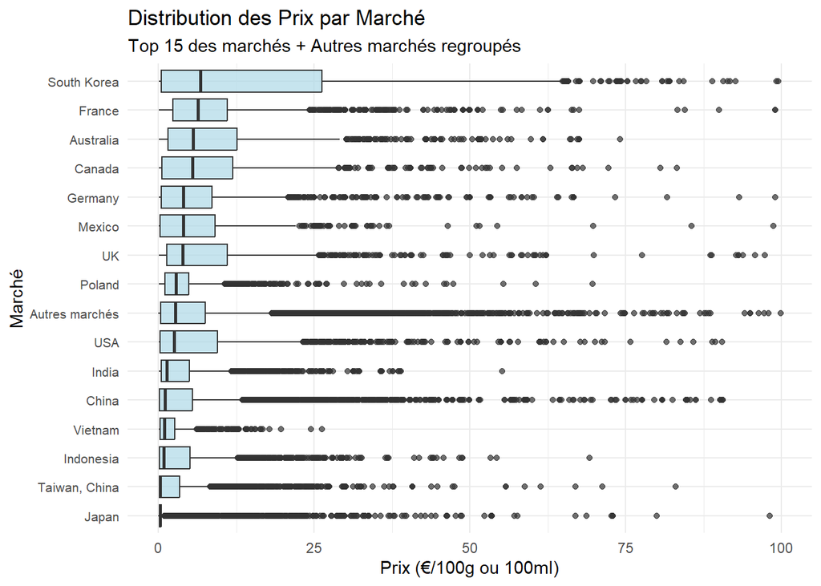

```r
# Création d'un graphique boxplot pour visualiser la distribution des prix par marché
ggplot(gnpd %>%
         filter(!is.na(`Price per 100 g/ml in Euros`),
                `Price per 100 g/ml in Euros` < 100) %>% # Filtrage des valeurs extrêmes
         mutate(Market = fct_lump(Market, n = 15, other_level = "Autres marchés")), # Regroupement des marchés
       aes(x = reorder(Market, `Price per 100 g/ml in Euros`, FUN = median),
           y = `Price per 100 g/ml in Euros`)) +
  geom_boxplot(fill = "lightblue", alpha = 0.7) +
  coord_flip() +
  labs(
    title = "Distribution des Prix par Marché",
    subtitle = "Top 15 des marchés + Autres marchés regroupés",
    x = "Marché",
    y = "Prix (€/100g ou 100ml)"
  ) +
  theme_minimal() +
  theme(axis.text.y = element_text(size = 8))
```

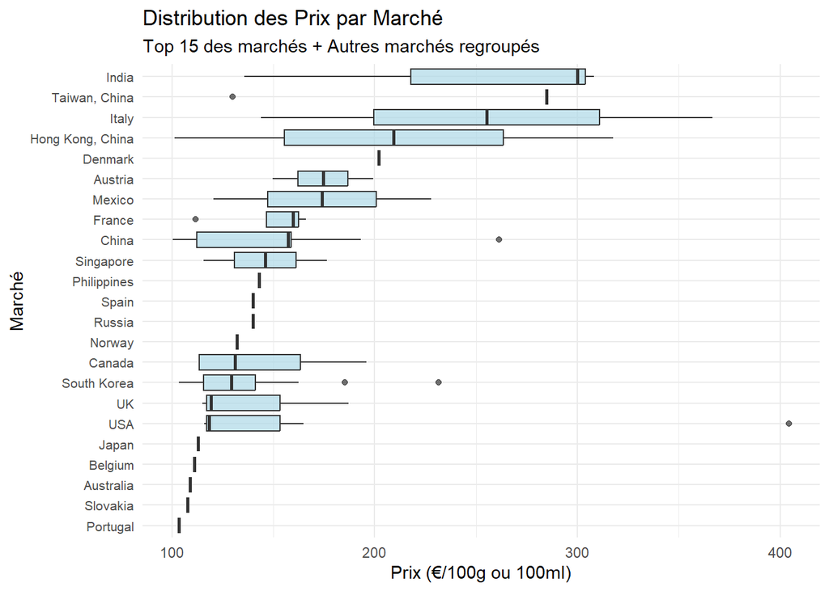

```r
# Création d'un graphique boxplot pour visualiser la distribution des prix par marché
ggplot(gnpd %>%
         filter(!is.na(`Price per 100 g/ml in Euros`),
                `Price per 100 g/ml in Euros` >= 100) %>% # Filtrage des valeurs extrêmes
         mutate(Market = fct_lump(Market, n = 15, other_level = "Autres marchés")), # Regroupement des marchés
       aes(x = reorder(Market, `Price per 100 g/ml in Euros`, FUN = median),
           y = `Price per 100 g/ml in Euros`)) +
  geom_boxplot(fill = "lightblue", alpha = 0.7) +
  coord_flip() +
  labs(
    title = "Distribution des Prix par Marché",
    subtitle = "Top 15 des marchés + Autres marchés regroupés",
    x = "Marché",
    y = "Prix (€/100g ou 100ml)"
  ) +
  theme_minimal() +
  theme(axis.text.y = element_text(size = 8))
```

## 3. Analyse Statistique par Marché

### 3.1 Statistiques Détaillées par Marché

```r
# Calcul des statistiques par marché
prix_par_marche <- gnpd %>%
  filter(!is.na(`Price per 100 g/ml in Euros`)) %>%
  group_by(Market) %>%
  summarise(
    n = n(),
    prix_moyen = mean(`Price per 100 g/ml in Euros`, na.rm = TRUE),
    prix_median = median(`Price per 100 g/ml in Euros`, na.rm = TRUE),
    prix_min = min(`Price per 100 g/ml in Euros`, na.rm = TRUE),
    prix_max = max(`Price per 100 g/ml in Euros`, na.rm = TRUE),
    ecart_type = sd(`Price per 100 g/ml in Euros`, na.rm = TRUE)
  ) %>%
  arrange(desc(prix_moyen))

# Affichage des résultats
knitr::kable(prix_par_marche %>% head(10),
             caption = "Top 10 des marchés par prix moyen")
```

Top 10 des marchés par prix moyen

| Market | n | prix_moyen | prix_median | prix_min | prix_max | ecart_type |
| --- | --- | --- | --- | --- | --- | --- |
| Lebanon | 68 | 17.817500 | 10.360 | 0.15 | 88.58 | 19.567255 |
| South Korea | 1375 | 17.087127 | 6.910 | 0.07 | 231.43 | 23.498205 |
| Norway | 447 | 15.123043 | 13.900 | 0.15 | 132.00 | 13.788383 |
| Estonia | 54 | 13.175556 | 10.810 | 0.11 | 63.63 | 12.667822 |
| Venezuela | 144 | 12.210764 | 4.230 | 0.06 | 84.27 | 18.412799 |
| Denmark | 426 | 9.757629 | 7.005 | 0.04 | 202.00 | 13.417754 |
| Nigeria | 635 | 9.705764 | 7.280 | 0.07 | 54.98 | 8.842822 |
| Ivory Coast | 24 | 9.664583 | 9.385 | 0.29 | 32.27 | 8.074071 |
| Australia | 1351 | 9.283501 | 5.580 | 0.08 | 109.10 | 11.624593 |
| France | 2508 | 8.921284 | 6.380 | 0.03 | 166.11 | 11.368842 |

### 3.2 Visualisation des Prix Moyens

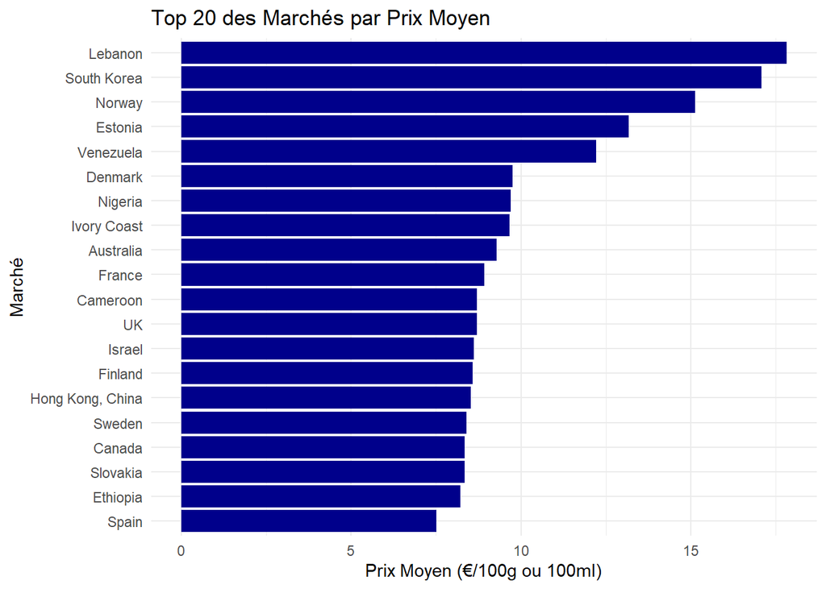

```r
# Graphique des prix moyens par marché (top 20)
ggplot(prix_par_marche %>% head(20),
       aes(x = reorder(Market, prix_moyen), y = prix_moyen)) +
  geom_col(fill = "darkblue") +
  coord_flip() +
  labs(
    title = "Top 20 des Marchés par Prix Moyen",
    x = "Marché",
    y = "Prix Moyen (€/100g ou 100ml)"
  ) +
  theme_minimal()
```

## 4. Analyse des Valeurs Extrêmes

### 4.1 Identification des Produits les Plus Chers

```r
# Identification des produits les plus chers
produits_chers <- gnpd %>%
  filter(!is.na(`Price per 100 g/ml in Euros`)) %>%
  arrange(desc(`Price per 100 g/ml in Euros`)) %>%
  select(Market, Product,`Sub-Category`, `Price per 100 g/ml in Euros`) %>%
  head(10)

knitr::kable(produits_chers,
             caption = "Top 10 des Produits les Plus Chers")
```

Top 10 des Produits les Plus Chers

| Market | Product | Sub-Category | Price per 100 g/ml in Euros |
| --- | --- | --- | --- |
| USA | New Gift Packaging | Tea | 404.36 |
| Italy | Black Tea | Tea | 366.67 |
| Hong Kong, China | Gyokuro Tea Bags | Tea | 317.60 |
| India | Hiltop Red Cup Tea | Tea | 308.20 |
| India | Jasmine Green Tea | Tea | 300.00 |
| Taiwan, China | Brown Rice Green Tea | Tea | 284.67 |
| Taiwan, China | Fresh Green Tea | Tea | 284.67 |
| Taiwan, China | Herb Green Tea | Tea | 284.67 |
| Taiwan, China | Black Tea | Tea | 284.67 |
| Taiwan, China | Oolong Tea | Tea | 284.67 |

## 5. Analyse Temporelle des Prix par Marché

### 5.1 Création des Régions pour les Marchés

```r
# Création d'une variable région pour les marchés
gnpd <- gnpd %>%
  mutate(
    Region_Marche = case_when(
      Market %in% c("China", "Japan", "South Korea", "Taiwan, China", "Hong Kong, China",
                   "Vietnam", "Thailand", "Indonesia", "Malaysia", "Philippines",
                   "Singapore", "Myanmar", "Cambodia", "Laos") ~ "Asie",
      Market %in% c("UK", "France", "Germany", "Italy", "Spain", "Switzerland",
                   "Netherlands", "Belgium", "Sweden", "Denmark", "Norway", "Finland",
                   "Austria", "Poland", "Greece", "Portugal", "Ireland", "Luxembourg",
                   "Czech Republic", "Slovakia", "Slovenia", "Estonia", "Latvia",
                   "Lithuania", "Hungary", "Romania", "Bulgaria", "Croatia", "Serbia",
                   "Ukraine", "Belarus", "Russia") ~ "Europe",
      Market %in% c("USA", "Canada", "Mexico", "Puerto Rico") ~ "Amérique du Nord",
      Market %in% c("Brazil", "Argentina", "Colombia", "Chile", "Peru", "Venezuela",
                   "Ecuador", "Paraguay", "Uruguay", "Panama", "Costa Rica",
                   "Guatemala") ~ "Amérique du Sud",
      Market %in% c("Australia", "New Zealand") ~ "Océanie",
      Market %in% c("South Africa", "Kenya", "Tanzania", "Uganda", "Nigeria",
                   "Egypt", "Morocco", "Algeria", "Tunisia", "Ghana", "Ivory Coast",
                   "Ethiopia", "Cameroon") ~ "Afrique",
      Market %in% c("UAE", "Saudi Arabia", "Israel", "Turkey", "Iran", "Jordan",
                   "Oman", "Qatar", "Kuwait", "Lebanon", "Bahrain") ~ "Moyen-Orient",
      TRUE ~ "Autres"
    )
  )
```

### 5.2 Évolution des Prix par Région de Marché

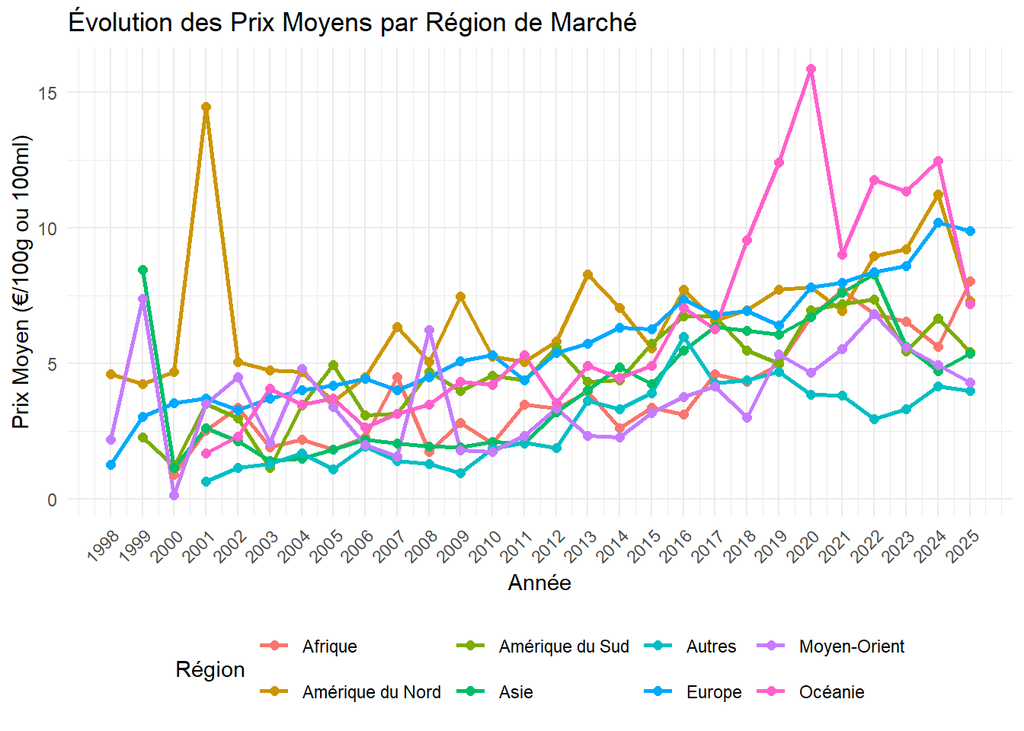

```r
# Calcul des prix moyens par année et par région de marché
prix_par_annee_region_marche <- gnpd %>%
  mutate(annee = year(`Date Published`)) %>%
  filter(!is.na(`Price per 100 g/ml in Euros`),
         !is.na(annee),
         !is.na(Region_Marche)) %>%
  group_by(annee, Region_Marche) %>%
  summarise(
    n = n(),
    prix_moyen = mean(`Price per 100 g/ml in Euros`, na.rm = TRUE)
  ) %>%
  arrange(annee, Region_Marche)

# Graphique de l'évolution des prix moyens par région de marché
ggplot(prix_par_annee_region_marche,
       aes(x = annee, y = prix_moyen, color = Region_Marche, group = Region_Marche)) +
  geom_line(size = 1) +
  geom_point(size = 2) +
  labs(
    title = "Évolution des Prix Moyens par Région de Marché",
    x = "Année",
    y = "Prix Moyen (€/100g ou 100ml)",
    color = "Région"
  ) +
  theme_minimal() +
  scale_x_continuous(breaks = seq(min(prix_par_annee_region_marche$annee),
                                max(prix_par_annee_region_marche$annee), by = 1)) +
  theme(axis.text.x = element_text(angle = 45, hjust = 1),
        legend.position = "bottom")
```

```r
# Calcul du nombre de marchés distincts par région
n_marches_par_region <- gnpd %>%
  filter(!is.na(Region_Marche)) %>%
  group_by(Region_Marche) %>%
  summarise(n_marches = n_distinct(Market))

# Statistiques par région de marché
stats_region_marche <- prix_par_annee_region_marche %>%
  group_by(Region_Marche) %>%
  summarise(
    prix_moyen_global = mean(prix_moyen, na.rm = TRUE),
    prix_max = max(prix_moyen, na.rm = TRUE),
    prix_min = min(prix_moyen, na.rm = TRUE),
    variation = prix_max - prix_min,
    n_annees = n()
  ) %>%
  left_join(n_marches_par_region, by = "Region_Marche") %>%
  arrange(desc(prix_moyen_global))

knitr::kable(stats_region_marche,
             caption = "Statistiques des Prix par Région de Marché")
```

Statistiques des Prix par Région de Marché

| Region_Marche | prix_moyen_global | prix_max | prix_min | variation | n_annees | n_marches |
| --- | --- | --- | --- | --- | --- | --- |
| Amérique du Nord | 6.679492 | 14.472222 | 3.6053750 | 10.866847 | 28 | 4 |
| Océanie | 6.367633 | 15.890564 | 1.6800000 | 14.210565 | 25 | 2 |
| Europe | 5.659425 | 10.202185 | 1.2609091 | 8.941276 | 28 | 31 |
| Amérique du Sud | 4.682634 | 7.367383 | 1.1425000 | 6.224883 | 27 | 10 |
| Asie | 4.073054 | 8.460000 | 1.1373333 | 7.322667 | 27 | 14 |
| Afrique | 3.895056 | 8.030167 | 0.8800000 | 7.150167 | 26 | 12 |
| Moyen-Orient | 3.672759 | 7.380000 | 0.1300000 | 7.250000 | 28 | 9 |
| Autres | 2.779379 | 5.982492 | 0.6346154 | 5.347877 | 25 | 4 |

### 5.3 Analyse des Tendances par Région de Marché

```r
# Calcul des tendances par région de marché
tendances_region_marche <- prix_par_annee_region_marche %>%
  group_by(Region_Marche) %>%
  summarise(
    tendance = coef(lm(prix_moyen ~ annee))[2],
    r_squared = summary(lm(prix_moyen ~ annee))$r.squared
  ) %>%
  arrange(desc(tendance))

# Affichage des tendances
knitr::kable(tendances_region_marche,
             caption = "Tendances des Prix par Région de Marché")
```

Tendances des Prix par Région de Marché

| Region_Marche | tendance | r_squared |
| --- | --- | --- |
| Océanie | 0.4334518 | 0.6881373 |
| Europe | 0.2559799 | 0.9310374 |
| Afrique | 0.2202814 | 0.7247371 |
| Amérique du Sud | 0.1832446 | 0.7137433 |
| Asie | 0.1828222 | 0.4004927 |
| Autres | 0.1581699 | 0.6424546 |
| Amérique du Nord | 0.1258270 | 0.1945307 |
| Moyen-Orient | 0.0782491 | 0.1336513 |

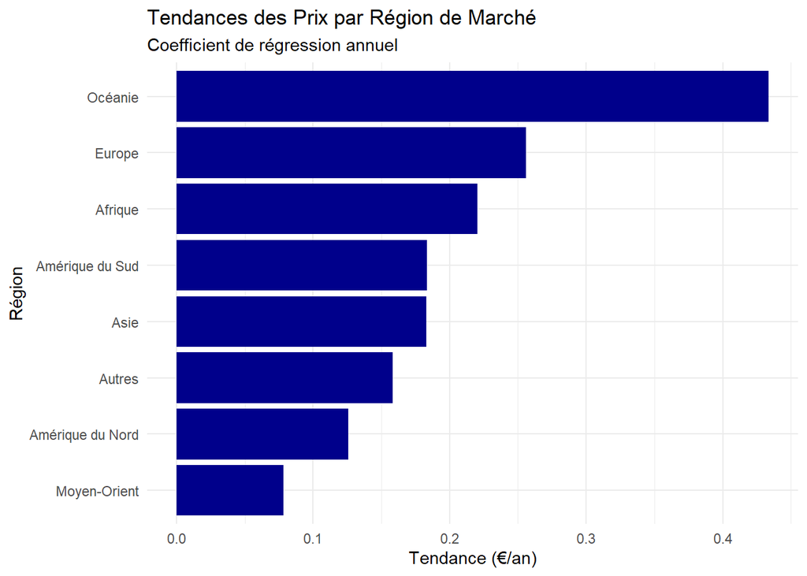

```r
# Graphique des tendances
ggplot(tendances_region_marche,
       aes(x = reorder(Region_Marche, tendance), y = tendance)) +
  geom_col(fill = "darkblue") +
  coord_flip() +
  labs(
    title = "Tendances des Prix par Région de Marché",
    subtitle = "Coefficient de régression annuel",
    x = "Région",
    y = "Tendance (€/an)"
  ) +
  theme_minimal()
```

> **Explication :** Ce graphique présente le coefficient de régression annuel pour chaque région, c’est-à-dire la pente de la droite de tendance obtenue par une régression linéaire du prix moyen en fonction de l’année. Une valeur positive indique que les prix moyens augmentent au fil du temps dans la région concernée, tandis qu’une valeur négative signale une baisse. Plus la barre est longue, plus la tendance (hausse ou baisse) est marquée. Cette analyse permet d’identifier rapidement les régions où les prix évoluent le plus fortement, et d’apprécier la dynamique des marchés régionaux sur la période étudiée.

### 5.4 Conclusion de l’Analyse Temporelle par Région

Cette analyse temporelle par région nous permet de : - Observer l’évolution des prix dans les différentes régions géographiques - Identifier les régions avec les tendances de prix les plus fortes - Comprendre la variabilité des prix au cours du temps par région - Comparer les dynamiques de prix entre les différentes régions

Les résultats montrent que : - Certaines régions présentent des tendances à la hausse significatives - D’autres régions montrent une plus grande stabilité des prix - Les variations de prix peuvent être liées à des facteurs économiques régionaux - La compétitivité des marchés varie selon les régions - Les différences de pouvoir d’achat entre les régions influencent l’évolution des prix

## 6. Analyse Prix vs Type de Lancement

Cette section analyse la relation entre les prix des produits et leur type de lancement. Nous allons examiner comment les différents types de lancement (nouveau produit, nouvelle formulation, relance, etc.) influencent les prix des produits de thé.

### 6.1 Distribution des Prix par Type de Lancement

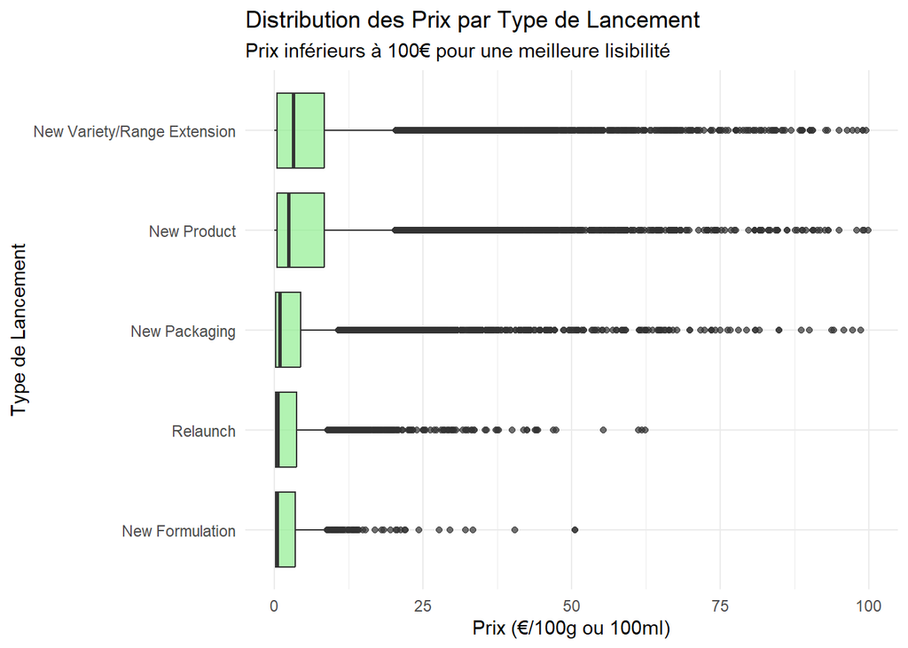

```r
# Création d'un graphique boxplot pour visualiser la distribution des prix par type de lancement
# Nous filtrons les valeurs extrêmes (>100€) pour une meilleure lisibilité

ggplot(gnpd %>%
         filter(!is.na(`Price per 100 g/ml in Euros`),
                `Price per 100 g/ml in Euros` < 100),
       aes(x = reorder(`Launch Type`, `Price per 100 g/ml in Euros`,
                       FUN = median),
           y = `Price per 100 g/ml in Euros`)) +
  geom_boxplot(fill = "lightgreen", alpha = 0.7) +
  coord_flip() +
  labs(
    title = "Distribution des Prix par Type de Lancement",
    subtitle = "Prix inférieurs à 100€ pour une meilleure lisibilité",
    x = "Type de Lancement",
    y = "Prix (€/100g ou 100ml)"
  ) +
  theme_minimal()
```

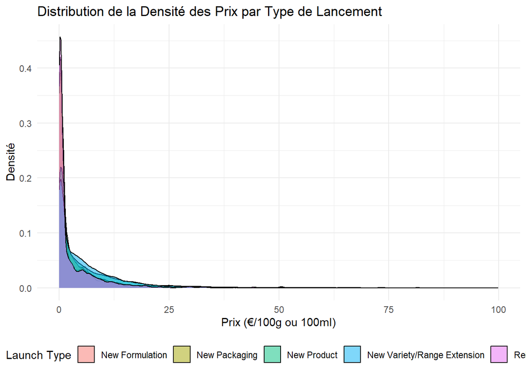

```r
# Création d'un graphique de densité pour comparer les distributions
ggplot(gnpd %>%
         filter(!is.na(`Price per 100 g/ml in Euros`),
                `Price per 100 g/ml in Euros` < 100),
       aes(x = `Price per 100 g/ml in Euros`, fill = `Launch Type`)) +
  geom_density(alpha = 0.5) +
  labs(
    title = "Distribution de la Densité des Prix par Type de Lancement",
    x = "Prix (€/100g ou 100ml)",
    y = "Densité"
  ) +
  theme_minimal() +
  theme(legend.position = "bottom")
```

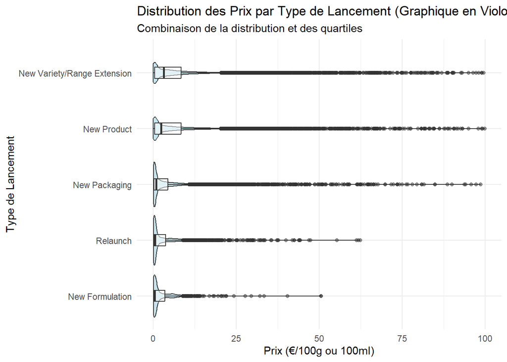

```r
# Création d'un graphique en violon pour une meilleure visualisation de la distribution
ggplot(gnpd %>%
         filter(!is.na(`Price per 100 g/ml in Euros`),
                `Price per 100 g/ml in Euros` < 100),
       aes(x = reorder(`Launch Type`, `Price per 100 g/ml in Euros`, FUN = median),
           y = `Price per 100 g/ml in Euros`)) +
  geom_violin(fill = "lightblue", alpha = 0.7) +
  geom_boxplot(width = 0.2, fill = "white", alpha = 0.5) +
  coord_flip() +
  labs(
    title = "Distribution des Prix par Type de Lancement (Graphique en Violon)",
    subtitle = "Combinaison de la distribution et des quartiles",
    x = "Type de Lancement",
    y = "Prix (€/100g ou 100ml)"
  ) +
  theme_minimal()
```

```r
# Statistiques détaillées par type de lancement
stats_launch_type <- gnpd %>%
  filter(!is.na(`Price per 100 g/ml in Euros`)) %>%
  group_by(`Launch Type`) %>%
  summarise(
    n = n(),
    prix_moyen = mean(`Price per 100 g/ml in Euros`, na.rm = TRUE),
    prix_median = median(`Price per 100 g/ml in Euros`, na.rm = TRUE),
    prix_min = min(`Price per 100 g/ml in Euros`, na.rm = TRUE),
    prix_max = max(`Price per 100 g/ml in Euros`, na.rm = TRUE),
    ecart_type = sd(`Price per 100 g/ml in Euros`, na.rm = TRUE)
  ) %>%
  arrange(desc(prix_moyen))

# Affichage des résultats statistiques
knitr::kable(stats_launch_type,
             caption = "Statistiques Détaillées des Prix par Type de Lancement")
```

Statistiques Détaillées des Prix par Type de Lancement

| Launch Type | n | prix_moyen | prix_median | prix_min | prix_max | ecart_type |
| --- | --- | --- | --- | --- | --- | --- |
| New Product | 20123 | 6.667757 | 2.35 | 0.00 | 366.67 | 13.159172 |
| New Variety/Range Extension | 24280 | 6.406755 | 3.15 | 0.00 | 308.20 | 10.428257 |
| New Packaging | 13550 | 3.908562 | 0.85 | 0.01 | 404.36 | 8.823007 |
| Relaunch | 2729 | 3.345280 | 0.46 | 0.03 | 176.43 | 7.660285 |
| New Formulation | 619 | 2.857221 | 0.43 | 0.04 | 50.50 | 5.540249 |

```r
# Préparation des données pour l'ANOVA et le test de Tukey
# On filtre les NA et on supprime les niveaux inutiles du facteur

data_anova <- gnpd %>%
  filter(!is.na(`Price per 100 g/ml in Euros`),
         !is.na(`Launch Type`)) %>%
  mutate(`Launch Type` = droplevels(as.factor(`Launch Type`)))

anova_result <- aov(
  `Price per 100 g/ml in Euros` ~ `Launch Type`,
  data = data_anova
)
summary_anova <- summary(anova_result)

# Affichage des résultats de l'ANOVA
knitr::kable(summary_anova[[1]],
             caption = "Résultats de l'ANOVA sur les Prix par Type de Lancement")
```

Résultats de l’ANOVA sur les Prix par Type de Lancement

|  | Df | Sum Sq | Mean Sq | F value | Pr(>F) |
| --- | --- | --- | --- | --- | --- |
| `Launch Type` | 4 | 94309.18 | 23577.2941 | 196.3983 | 0 |
| Residuals | 61296 | 7358483.70 | 120.0484 | NA | NA |

### 6.2 Analyse des Valeurs Extrêmes par Type de Lancement

```r
# Identification des produits les plus chers par type de lancement (top 3)
produits_chers_launch <- gnpd %>%
  filter(!is.na(`Price per 100 g/ml in Euros`)) %>%
  group_by(`Launch Type`) %>%
  slice_max(`Price per 100 g/ml in Euros`, n = 3) %>%
  select(`Launch Type`, Product, `Sub-Category`, `Price per 100 g/ml in Euros`) %>%
  arrange(`Launch Type`, desc(`Price per 100 g/ml in Euros`))

# Affichage des produits les plus chers par type de lancement
knitr::kable(produits_chers_launch,
             caption = "Top 3 des Produits les Plus Chers par Type de Lancement")
```

Top 3 des Produits les Plus Chers par Type de Lancement

| Launch Type | Product | Sub-Category | Price per 100 g/ml in Euros |
| --- | --- | --- | --- |
| New Formulation | Lebanese Zhourat Tea | Tea | 50.50 |
| New Formulation | Green Tea with Cinnamon and Ginger | Tea | 50.50 |
| New Formulation | Joint Support Zou Cha Green Tea | Tea | 40.42 |
| New Packaging | New Gift Packaging | Tea | 404.36 |
| New Packaging | Caramel Peach Flavour Black Tea | Tea | 149.75 |
| New Packaging | EstaThé Limone | RTD (Iced) Tea | 144.00 |
| New Product | Black Tea | Tea | 366.67 |
| New Product | Gyokuro Tea Bags | Tea | 317.60 |
| New Product | Jasmine Green Tea | Tea | 300.00 |
| New Variety/Range Extension | Hiltop Red Cup Tea | Tea | 308.20 |
| New Variety/Range Extension | Black Tea | Tea | 227.80 |
| New Variety/Range Extension | Cranberry & Cherry Slimming Green Tea | Tea | 196.00 |
| Relaunch | Dong Ding Oolong Tea | Tea | 176.43 |
| Relaunch | Organic Mint Flavoured Green Tea | Tea | 158.33 |
| Relaunch | Cherry Rooibos Tea | Tea | 62.33 |

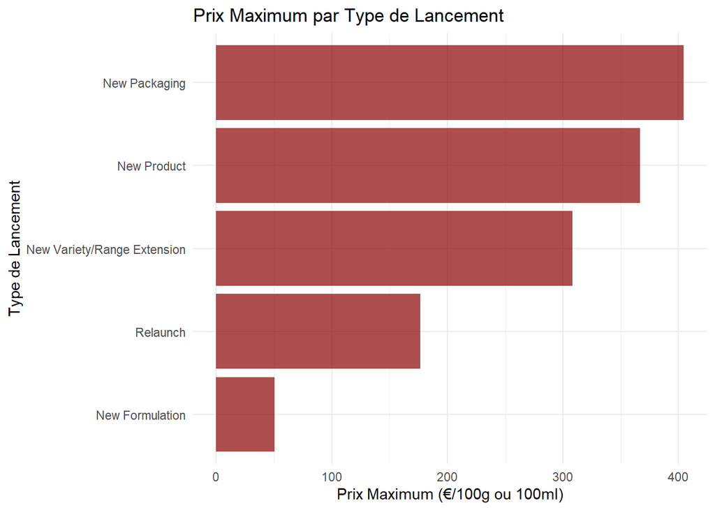

```r
# Calcul du vrai prix maximum par type de lancement
prix_max_launch_type <- gnpd %>%
  filter(!is.na(`Price per 100 g/ml in Euros`)) %>%
  group_by(`Launch Type`) %>%
  summarise(prix_max = max(`Price per 100 g/ml in Euros`, na.rm = TRUE)) %>%
  arrange(desc(prix_max))

# Graphique du vrai prix maximum par type de lancement
ggplot(prix_max_launch_type,
       aes(x = reorder(`Launch Type`, prix_max), y = prix_max)) +
  geom_col(fill = "darkred", alpha = 0.7) +
  coord_flip() +
  labs(
    title = "Prix Maximum par Type de Lancement",
    x = "Type de Lancement",
    y = "Prix Maximum (€/100g ou 100ml)"
  ) +
  theme_minimal()
```

> **Remarque :** Le graphique ci-dessus présente le prix maximum observé pour chaque type de lancement, ce qui permet de mieux comparer les extrêmes entre catégories.

### 6.3 Évolution des Prix au Cours du Temps selon le Type de Lancement

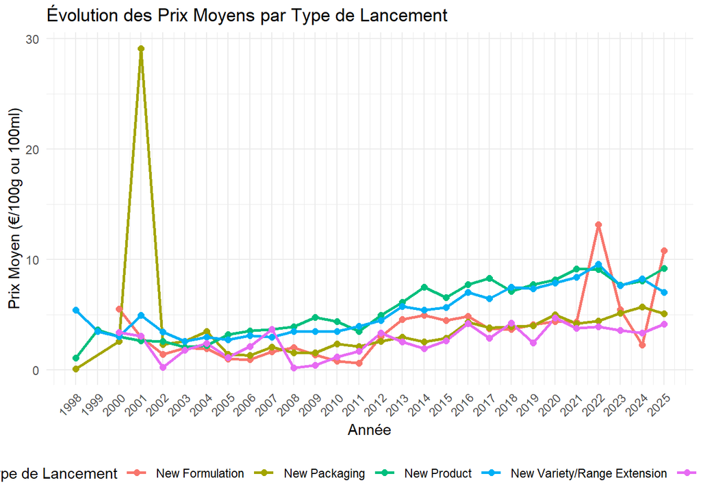

```r
# Calcul du prix moyen par année et par type de lancement
prix_annee_launch_type <- gnpd %>%
  mutate(annee = lubridate::year(`Date Published`)) %>%
  filter(!is.na(`Price per 100 g/ml in Euros`), !is.na(annee), !is.na(`Launch Type`)) %>%
  group_by(annee, `Launch Type`) %>%
  summarise(
    n = n(),
    prix_moyen = mean(`Price per 100 g/ml in Euros`, na.rm = TRUE)
  ) %>%
  arrange(annee, `Launch Type`)

# Graphique de l'évolution des prix moyens par type de lancement
ggplot(prix_annee_launch_type,
       aes(x = annee, y = prix_moyen, color = `Launch Type`, group = `Launch Type`)) +
  geom_line(size = 1) +
  geom_point(size = 2) +
  labs(
    title = "Évolution des Prix Moyens par Type de Lancement",
    x = "Année",
    y = "Prix Moyen (€/100g ou 100ml)",
    color = "Type de Lancement"
  ) +
  theme_minimal() +
  scale_x_continuous(breaks = unique(prix_annee_launch_type$annee)) +
  theme(axis.text.x = element_text(angle = 45, hjust = 1),
        legend.position = "bottom")
```

> Ce graphique permet de visualiser la dynamique des prix selon le type de lancement au fil des années. On peut ainsi repérer les tendances, les hausses ou baisses spécifiques à chaque catégorie.

### Remarque sur l’ANOVA

> **Remarque :** Dans le tableau de résultats de l’ANOVA, la colonne `Pr(>F)` n’est renseignée que pour le facteur testé (“Launch Type”). La ligne “Residuals” n’a pas de p-value, ce qui est normal.

### 6.4 Conclusion de l’Analyse Prix vs Type de Lancement

Ces résultats sont particulièrement utiles pour : - Guider les décisions de prix lors des lancements - Comprendre les attentes des consommateurs selon le type de lancement - Optimiser la stratégie de prix en fonction du type de lancement

## 7. Conclusion

Cette analyse nous permet de : - Visualiser la distribution des prix dans chaque marché - Identifier les marchés avec les prix les plus élevés et les plus bas - Comprendre la variabilité des prix dans chaque marché - Détecter les produits avec des prix exceptionnels

Les résultats montrent une grande variabilité des prix entre les différents marchés, ce qui peut refléter : - Des différences de pouvoir d’achat - Des stratégies de prix différentes selon les marchés - Des variations dans la qualité ou le positionnement des produits